# OpenClassrooms - parcours Data Analyst Business Intelligence - P8

# Milestone 1 - Analyse des données

Dans cette partie nous allons analyser le jeu de données que nous avons à notre disposition. Notre objectif est de comprendre les relations entre les variables, et surtout, celles qui influent sur le prix des transactions immobilières. Grâce à ce travail, nous pourrons ne conserver que les variables qui seront utiles à l'apprentissage de notre algorithme.

## 1.Type des données

La première étape à réaliser est d'importer les données dans le notebook et d'opérer des transformations sur les variables si celles-ci s'imposent (exemple : nettoyage ou changement de type des variables, etc.).

```python
from google.colab import drive
drive.mount('/content/drive')
```

```python
#On importe les librairies que nous utiliserons pour traiter les données et les visualiser
import pandas as pd, numpy as np
# N'oubliez pas d'avoir installé les librairies pandas, numpy et matplotlib via la commande pip
```

```python
#On importe les données dans un dataframe
dataset=pd.read_excel('/content/drive/MyDrive/historique_immobilier_paris_2017_2021_vdef2.xlsx')
dataset.head(5)
```

|  | date_mutation | valeur_fonciere | adresse_numero | adresse_nom_voie | code_postal | nom_commune | code_type_local | type_local | surface_reelle |
| --- | --- | --- | --- | --- | --- | --- | --- | --- | --- |
| 0 | 2017-01-03 | 5.505597e+05 | 8 | RUE DES COUTURES SAINT GERVAIS | 75003 | Paris 3e Arrondissement | 2 | Appartement | 50 |
| 1 | 2017-01-12 | 1.576492e+06 | 32 | AV MARCEAU | 75008 | Paris 8e Arrondissement | 2 | Appartement | 163 |
| 2 | 2017-01-10 | 6.577574e+05 | 52 | RUE DU FAUBOURG SAINT HONORE | 75008 | Paris 8e Arrondissement | 2 | Appartement | 66 |
| 3 | 2017-01-10 | 2.500868e+05 | 64 | RUE DU VERTBOIS | 75003 | Paris 3e Arrondissement | 2 | Appartement | 22 |
| 4 | 2017-01-13 | 1.762667e+05 | 25 | RUE DES LAVANDIERES STE OPPORT | 75001 | Paris 1er Arrondissement | 2 | Appartement | 15 |

Attention, si l'opération ci-dessus ne marche pas, il se peut que le package "openpyxl" ne soit pas présent sur votre ordinateur. Si c'est le cas vous pouvez l'installer en éxécutant la commande : pip install openpyxl ou conda install openpyxl.

```python
#On vérifie que le type des données attribué par pandas est cohérent
dataset.dtypes
```

|  | 0 |
| --- | --- |
| date_mutation | datetime64[ns] |
| valeur_fonciere | float64 |
| adresse_numero | int64 |
| adresse_nom_voie | object |
| code_postal | int64 |
| nom_commune | object |
| code_type_local | int64 |
| type_local | object |
| surface_reelle | int64 |

**dtype:** object

### 2. Regardons les différents types de biens immobiliers que nous avons dans nos données :

```python
print('la liste des différents types de biens immobiliers que nous avons dans les données est :')
dataset[['code_type_local','type_local']].drop_duplicates()
```

```
la liste des différents types de biens immobiliers que nous avons dans les données est :
```

|  | code_type_local | type_local |
| --- | --- | --- |
| 0 | 2 | Appartement |
| 18 | 4 | Local industriel. commercial ou assimilé |

On observe qu'il y a 2 types de biens les appartements et les locaux industriels commerciaux ou assimilé, et que leurs codes types sont 2 et 4.

### 3. Nombre de transactions

```python
#On verifie le nombre de transactions que nous avons dans notre dataframe
print('le nombre de transactions dans les données est '+ str(np.shape(dataset)[0]))
print('le nombre de transactions pour les appartements dans les données est '+ str(np.shape(dataset.loc[dataset['code_type_local']==2])[0]))
print('le nombre de transactions pour les locaux commerciaux dans les données est '+ str(np.shape(dataset.loc[dataset['code_type_local']==4])[0]))
```

```
le nombre de transactions dans les données est 26196
le nombre de transactions pour les appartements dans les données est 24353
le nombre de transactions pour les locaux commerciaux dans les données est 1843
```

### 4. interval de l'historique des données

```python
#On vérifie également la plage de l'historique disponible
print('la première date de transaction dans les données est le '+str(dataset['date_mutation'].min()))
print('la dernière date de transaction dans les données est le '+str(dataset['date_mutation'].max()))
```

```
la première date de transaction dans les données est le 2017-01-02 00:00:00
la dernière date de transaction dans les données est le 2021-12-31 00:00:00
```

## Commençons à analyser les données

Maintenant nous allons analyser les données historiques pour les 2 différents types de biens immobiliers en essayant d'identifier les relations entre les variables. Mais avant cela, il nous faudra pouvoir comparer les biens entre eux, et pour cela nous allons créer une colonne du prix au metre carré.

```python
dataset['prix_metre_carre']=dataset['valeur_fonciere']/dataset['surface_reelle']
```

Maintenant, analysons les appartements.

### 5. Evolution du prix au metre carré des appartements dans Paris

```python
#On retire les colonnes qui sont à priori inutiles ET nous allons nous concentrer sur les appartements dans un premier temps
dataset_appartement=dataset.drop(columns=['adresse_numero','adresse_nom_voie','code_type_local','nom_commune'])[dataset['code_type_local']==2]
dataset_appartement.head(5)
```

|  | date_mutation | valeur_fonciere | code_postal | type_local | surface_reelle | prix_metre_carre |
| --- | --- | --- | --- | --- | --- | --- |
| 0 | 2017-01-03 | 5.505597e+05 | 75003 | Appartement | 50 | 11011.193562 |
| 1 | 2017-01-12 | 1.576492e+06 | 75008 | Appartement | 163 | 9671.732877 |
| 2 | 2017-01-10 | 6.577574e+05 | 75008 | Appartement | 66 | 9966.020548 |
| 3 | 2017-01-10 | 2.500868e+05 | 75003 | Appartement | 22 | 11367.582877 |
| 4 | 2017-01-13 | 1.762667e+05 | 75001 | Appartement | 15 | 11751.113836 |

```python
#Préparons un dataframe en regroupant les prix moyens de ventes des appartements par année avec la surface moyenne associée
viz1=dataset_appartement[['date_mutation','prix_metre_carre']].groupby(dataset_appartement.date_mutation.dt.year).mean()
viz1
```

| date_mutation | date_mutation | prix_metre_carre |
| --- | --- | --- |
| 2017 | 2017-06-30 18:30:17.287745024 | 9492.859195 |
| 2018 | 2018-07-05 14:51:54.893616896 | 10031.403432 |
| 2019 | 2019-07-06 02:52:29.571510272 | 10562.712581 |
| 2020 | 2020-07-07 13:59:09.406348544 | 10674.872650 |
| 2021 | 2021-07-08 16:36:36.974216960 | 10455.600126 |

On constate que la moyenne des prix de vente des appartements à Paris a augmenté entre 2017 et 2020 avec un légère baisse en 2021. Nous allons créer un graphique pour mieux le visualiser.

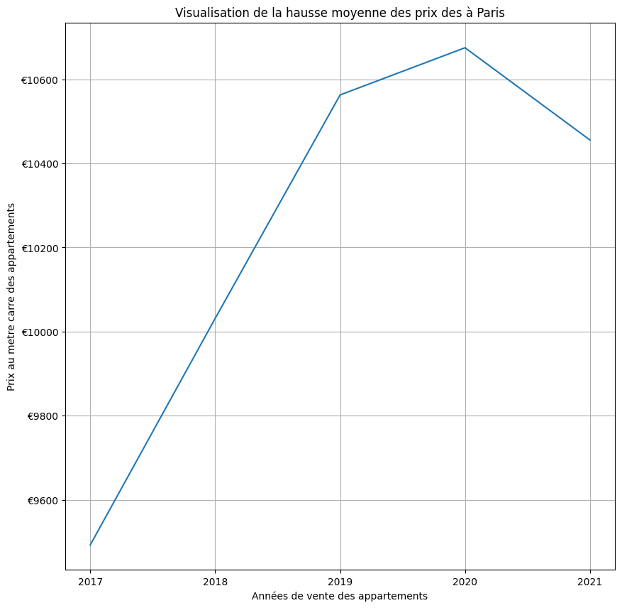

```python
#Création d'un graphique pour visualiser la hausse de la moyenne des prix
import matplotlib.pyplot as plt
import matplotlib.ticker as ticker
plt.figure(figsize=(10,10))
plt.plot(['2017','2018','2019','2020','2021'],viz1['prix_metre_carre'])
plt.xlabel('Années de vente des appartements')
plt.ylabel('Prix au metre carre des appartements')
formatter = ticker.FormatStrFormatter('€%d')
plt.gca().yaxis.set_major_formatter(formatter)
plt.grid()
plt.title('Visualisation de la hausse moyenne des prix des à Paris')
plt.show()
```

### 6. Différences de prix au metre carré entre les arrondissements

Maintenant nous allons chercher à afficher l'évolution des prix par arrondissement. Vérifions la liste des arrondissements que nous avons dans nos données. Normalement à Paris nous avons 20 codes postaux différents, 1 par arrondissement allant de 75001 à 75020.

```python
#Liste des codes postaux dans nos données.
np.unique(dataset_appartement['code_postal'])
```

```
array([75001, 75002, 75003, 75004, 75005, 75006, 75007, 75008, 75009,
       75010, 75011, 75012, 75013, 75014, 75015, 75016, 75017, 75018,
       75019, 75020])
```

```python
#Créeons un dataframe pour une deuxième visualisation avec l'evolution des prix par arrondissement
viz2=dataset_appartement[['date_mutation','prix_metre_carre','code_postal']].groupby([dataset_appartement.date_mutation.dt.year,'code_postal'],as_index=False).mean()
viz2
```

|  | code_postal | date_mutation | prix_metre_carre |
| --- | --- | --- | --- |
| 0 | 75001 | 2017-07-01 19:18:37.241379328 | 11762.706289 |
| 1 | 75002 | 2017-07-08 22:53:01.395348736 | 10920.126562 |
| 2 | 75003 | 2017-06-29 05:11:34.736841984 | 11679.818729 |
| 3 | 75004 | 2017-07-09 21:06:40.000000000 | 12407.227522 |
| 4 | 75005 | 2017-07-03 23:39:13.846153728 | 11306.752404 |
| ... | ... | ... | ... |
| 95 | 75016 | 2021-07-10 02:29:55.068493056 | 10790.307817 |
| 96 | 75017 | 2021-07-03 17:16:17.483443968 | 10372.368746 |
| 97 | 75018 | 2021-07-08 20:54:45.077187072 | 9665.640629 |
| 98 | 75019 | 2021-07-09 04:29:13.043478272 | 8828.586057 |
| 99 | 75020 | 2021-07-06 02:47:33.818181888 | 9114.398249 |

100 rows × 3 columns

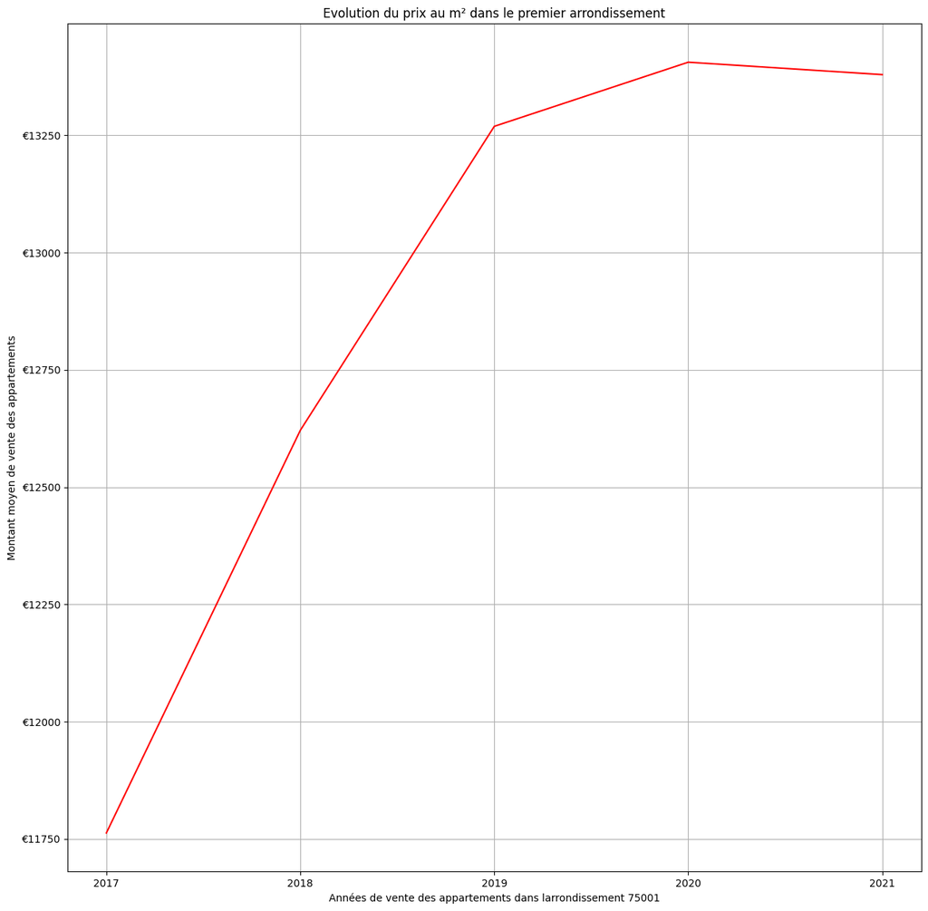

```python
#Création d'un graphique pour visualiser la hausse de la moyenne des prix au metre carré dans le premier arrondissement
plt.figure(figsize=(15,15))
plt.plot(['2017','2018','2019','2020','2021'],viz2.loc[viz2['code_postal']==75001]['prix_metre_carre'],color='red')
plt.xlabel('Années de vente des appartements dans larrondissement 75001')
plt.ylabel('Montant moyen de vente des appartements')
formatter = ticker.FormatStrFormatter('€%d')
plt.gca().yaxis.set_major_formatter(formatter)
plt.grid()
plt.title('Evolution du prix au m² dans le premier arrondissement')
plt.show()
```

Nous allons ajouter à cette visualisation tous les autres arrondissement avec une couleur différente.

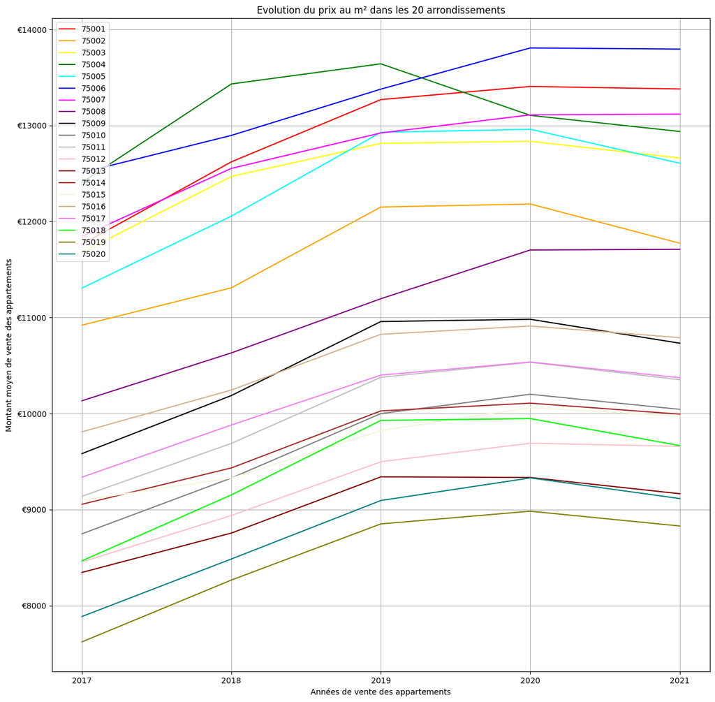

```python
#On affiche l'évolution du prix au m² par arrondissement dans Paris
plt.figure(figsize=(15,15))
interval_historique=['2017','2018','2019','2020','2021']
plt.plot(interval_historique,viz2.loc[viz2['code_postal']==75001]['prix_metre_carre'], color='red',label='75001')
plt.plot(interval_historique,viz2.loc[viz2['code_postal']==75002]['prix_metre_carre'], color='orange',label='75002')
plt.plot(interval_historique,viz2.loc[viz2['code_postal']==75003]['prix_metre_carre'], color='yellow',label='75003')
plt.plot(interval_historique,viz2.loc[viz2['code_postal']==75004]['prix_metre_carre'], color='green',label='75004')
plt.plot(interval_historique,viz2.loc[viz2['code_postal']==75005]['prix_metre_carre'], color='cyan',label='75005')
plt.plot(interval_historique,viz2.loc[viz2['code_postal']==75006]['prix_metre_carre'], color='blue',label='75006')
plt.plot(interval_historique,viz2.loc[viz2['code_postal']==75007]['prix_metre_carre'], color='magenta',label='75007')
plt.plot(interval_historique,viz2.loc[viz2['code_postal']==75008]['prix_metre_carre'], color='purple',label='75008')
plt.plot(interval_historique,viz2.loc[viz2['code_postal']==75009]['prix_metre_carre'], color='black',label='75009')
plt.plot(interval_historique,viz2.loc[viz2['code_postal']==75010]['prix_metre_carre'], color='gray',label='75010')
plt.plot(interval_historique,viz2.loc[viz2['code_postal']==75011]['prix_metre_carre'], color='silver',label='75011')
plt.plot(interval_historique,viz2.loc[viz2['code_postal']==75012]['prix_metre_carre'], color='pink',label='75012')
plt.plot(interval_historique,viz2.loc[viz2['code_postal']==75013]['prix_metre_carre'], color='maroon',label='75013')
plt.plot(interval_historique,viz2.loc[viz2['code_postal']==75014]['prix_metre_carre'], color='brown',label='75014')
plt.plot(interval_historique,viz2.loc[viz2['code_postal']==75015]['prix_metre_carre'], color='beige',label='75015')
plt.plot(interval_historique,viz2.loc[viz2['code_postal']==75016]['prix_metre_carre'], color='tan',label='75016')
plt.plot(interval_historique,viz2.loc[viz2['code_postal']==75017]['prix_metre_carre'], color='violet',label='75017')
plt.plot(interval_historique,viz2.loc[viz2['code_postal']==75018]['prix_metre_carre'], color='lime',label='75018')
plt.plot(interval_historique,viz2.loc[viz2['code_postal']==75019]['prix_metre_carre'], color='olive',label='75019')
plt.plot(interval_historique,viz2.loc[viz2['code_postal']==75020]['prix_metre_carre'], color='teal',label='75020')
plt.xlabel('Années de vente des appartements')
plt.ylabel('Montant moyen de vente des appartements')
formatter = ticker.FormatStrFormatter('€%d')
plt.gca().yaxis.set_major_formatter(formatter)
plt.grid()
plt.title('Evolution du prix au m² dans les 20 arrondissements')
plt.legend(loc='upper left')
plt.show()
```

On observe que globalement les prix au metre carré ont augmenté dans tous les arrondissements.

Nous retenons surtout que cette dimension est donc très importante pour notre future algorithme car les prix sont très différents entre les différents arrondissements de Paris. Environ 13 mille euros dans le 7ème arrondissement en 2021 pour 9 mille euros dans le 19ème arrondissement.

```python
#Observons les prix pour 2021 pour vérifier cette différence de prix
viz2.tail(20)
```

|  | code_postal | date_mutation | prix_metre_carre |
| --- | --- | --- | --- |
| 80 | 75001 | 2021-07-11 08:45:42.857142784 | 13379.498578 |
| 81 | 75002 | 2021-07-11 21:30:40.000000000 | 11773.445419 |
| 82 | 75003 | 2021-07-03 19:49:33.913043456 | 12660.546567 |
| 83 | 75004 | 2021-06-29 00:14:15.445544448 | 12936.958334 |
| 84 | 75005 | 2021-07-21 23:07:03.529411840 | 12605.843983 |
| 85 | 75006 | 2021-07-23 05:42:51.428571392 | 13795.048958 |
| 86 | 75007 | 2021-07-25 04:48:00.000000000 | 13118.135985 |
| 87 | 75008 | 2021-06-23 03:57:31.546391808 | 11710.094574 |
| 88 | 75009 | 2021-07-11 06:19:17.142857216 | 10732.184387 |
| 89 | 75010 | 2021-07-19 06:00:00.000000000 | 10043.466941 |
| 90 | 75011 | 2021-07-22 16:33:38.328840960 | 10351.644701 |
| 91 | 75012 | 2021-07-16 01:36:00.000000000 | 9657.980179 |
| 92 | 75013 | 2021-07-03 09:13:50.769230848 | 9164.625982 |
| 93 | 75014 | 2021-07-03 16:00:00.000000000 | 9993.616203 |
| 94 | 75015 | 2021-06-20 17:44:45.968819712 | 9971.240600 |
| 95 | 75016 | 2021-07-10 02:29:55.068493056 | 10790.307817 |
| 96 | 75017 | 2021-07-03 17:16:17.483443968 | 10372.368746 |
| 97 | 75018 | 2021-07-08 20:54:45.077187072 | 9665.640629 |
| 98 | 75019 | 2021-07-09 04:29:13.043478272 | 8828.586057 |
| 99 | 75020 | 2021-07-06 02:47:33.818181888 | 9114.398249 |

### 7. Prix au metre carré par transaction dans un arrondissement

```python
#Vérifions le nombre de transaction dans le 6ème car le prix semble élevé
np.shape(dataset_appartement.loc[dataset_appartement['code_postal']==75006])[0]
```

```
709
```

Ce n'est pas une erreur, il y a 709 transactions dans le 6ème sur lesquelles le prix moyen a été calculé. Mais peut-être qu'une seule transaction hors norme est responsable de ce prix moyen de 14 mille euros du metre carré.

Affichons l'historique des transactions pour visualiser la dispersion des données :

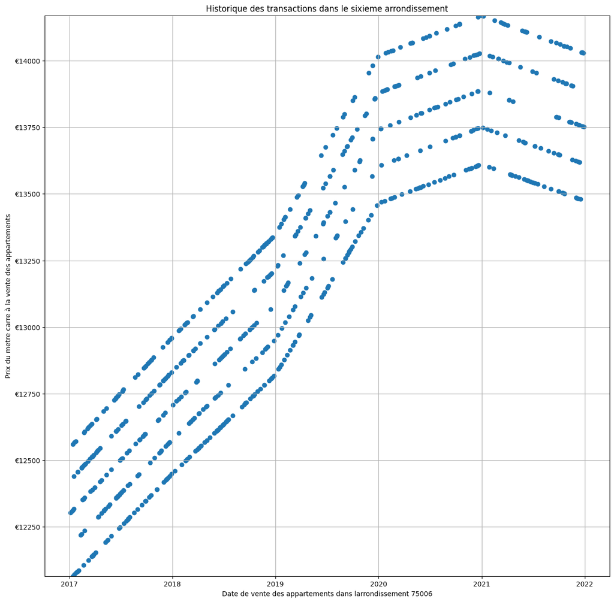

```python
cp=75006
plt.figure(figsize=(15,15))
plt.scatter(dataset_appartement.loc[dataset_appartement['code_postal']==cp]['date_mutation'],dataset_appartement.loc[dataset_appartement['code_postal']==cp]['prix_metre_carre'])
plt.xlabel('Date de vente des appartements dans larrondissement 75006')
plt.ylabel('Prix du metre carre à la vente des appartements')
formatter = ticker.FormatStrFormatter('€%d')
plt.gca().yaxis.set_major_formatter(formatter)
plt.ylim(dataset_appartement.loc[dataset_appartement['code_postal']==cp]['prix_metre_carre'].min(),dataset_appartement.loc[dataset_appartement['code_postal']==cp]['prix_metre_carre'].max())
plt.grid(which='both')
plt.title('Historique des transactions dans le sixieme arrondissement')
plt.show()
```

On observe que le prix de 14 mille euros du metre carre est bien lié à une distribution des prix autour de cette moyenne malgré la dispersion des données.

Pour nous rassurer sur la relation entre les données nous allons utiliser un test statistique de corrélation.

### 8. Vérification de la relation entre le prix au m² et la date dans le 6ème arrondissement par le calcul du coefficient de corrélation de Pearson

Pour cette distribution nous allons calculer le coefficient de corrélation de Pearson. La relation entre le prix au metre carré et la date n'est pas forcément linéaire mais elle s'en rapproche suffisamment pour que cette analyse soit pertinente (voir l'évolution du prix au metre carré globale montrée plus haut, on a presque une droite sauf entre 2020 et 2021). Ce qui nous interesse c'est de prouver que le temps a une influence sur le prix.

```python
#On calcule la corrélation de Spearman
from scipy import stats
stats.pearsonr((dataset_appartement.loc[dataset_appartement['code_postal']==75006]['date_mutation'].astype('datetime64[s]').astype('int64') / 10**9), dataset_appartement.loc[dataset_appartement['code_postal']==75006]['prix_metre_carre'])
```

```
PearsonRResult(statistic=np.float64(0.903844603149148), pvalue=np.float64(7.108378962571935e-263))
```

Le coefficient de corrélation est de 0,90 avec une pvalue très inférieure au seuil de à 0.05 donc nous pouvons confirmer la corrélation.

### 9. Vérification de la relation entre la valeur fonciere et la surface

```python
stats.pearsonr(dataset_appartement.loc[dataset_appartement['code_postal']==75006]['surface_reelle'],dataset_appartement.loc[dataset_appartement['code_postal']==75006]['valeur_fonciere'])
```

```
PearsonRResult(statistic=np.float64(0.9977572898250296), pvalue=np.float64(0.0))
```

Le coefficient de corrélation est de 0.99 avec une pvalue très inférieure au seuil de 0.05. La relation est donc confirmée.

Regardons maintenant si le type de bien à une influence sur le prix au metre carré également.

### 10. Analyse des locaux industriels, commerciaux et assimilés

```python
#On crée un dataset qui ne contient que les locaux commerciaux et on ajoute le prix au metre carré
dataset_locaux=dataset.drop(columns=['adresse_numero','adresse_nom_voie','nom_commune'])[dataset['code_type_local']==4]
dataset_locaux['prix_metre_carre']=dataset_locaux['valeur_fonciere']/dataset_locaux['surface_reelle']
dataset_locaux.head(5)
```

|  | date_mutation | valeur_fonciere | code_postal | code_type_local | type_local | surface_reelle | prix_metre_carre |
| --- | --- | --- | --- | --- | --- | --- | --- |
| 18 | 2017-02-01 | 3.113277e+06 | 75003 | 4 | Local industriel. commercial ou assimilé | 250 | 12453.109192 |
| 29 | 2017-02-17 | 1.164375e+06 | 75003 | 4 | Local industriel. commercial ou assimilé | 95 | 12256.581685 |
| 34 | 2017-02-20 | 3.802522e+05 | 75003 | 4 | Local industriel. commercial ou assimilé | 31 | 12266.199603 |
| 91 | 2017-03-09 | 3.623842e+05 | 75001 | 4 | Local industriel. commercial ou assimilé | 29 | 12496.006027 |
| 109 | 2017-03-29 | 3.159072e+05 | 75003 | 4 | Local industriel. commercial ou assimilé | 25 | 12636.289027 |

```python
#Préparons un dataframe en regroupant les prix au metre carré moyens des ventes par année
viz6=dataset_locaux[['date_mutation','prix_metre_carre']].groupby(dataset_locaux.date_mutation.dt.year).mean()
viz7=dataset_appartement[['date_mutation','prix_metre_carre']].groupby(dataset_appartement.date_mutation.dt.year).mean()
viz6
```

| date_mutation | date_mutation | prix_metre_carre |
| --- | --- | --- |
| 2017 | 2017-07-19 15:57:14.957020160 | 10949.909217 |
| 2018 | 2018-07-10 13:15:53.846153728 | 11569.499180 |
| 2019 | 2019-07-12 00:36:39.999999744 | 11960.132050 |
| 2020 | 2020-07-05 07:34:17.142857216 | 11966.470204 |
| 2021 | 2021-07-23 15:21:36.000000256 | 12006.488691 |

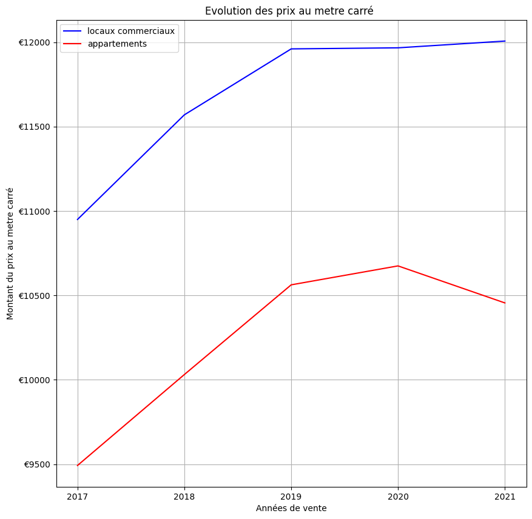

```python
#Création d'un graphique pour visualiser la hausse de la moyenne des prix
plt.figure(figsize=(10,10))
plt.plot(['2017','2018','2019','2020','2021'],viz6['prix_metre_carre'],label='locaux commerciaux',color='blue')
plt.plot(['2017','2018','2019','2020','2021'],viz7['prix_metre_carre'],label='appartements',color='red')
plt.xlabel('Années de vente')
plt.ylabel('Montant du prix au metre carré')
plt.legend()
formatter = ticker.FormatStrFormatter('€%d')
plt.gca().yaxis.set_major_formatter(formatter)
plt.grid()
plt.title('Evolution des prix au metre carré ')
plt.show()
```

Le prix au metre carré des locaux commerciaux est proche du prix des appartements mais on observe néanmoins une différence, nous choisissons de garder ce facteur en considération.

Après ces analyses, nous pouvons conclure que les dimensions à utiliser pour prédire le prix au m² sont :

- la surface du bien immobilier,
- la date considérée,
- la localisation (code_postal),
- le type de bien.